# Statistical inference with the GSS data

## Setup

### Load packages

```r
library(ggplot2)
library(dplyr)
library(statsr)
```

### Load data

```r
load("gss.Rdata")
```

## Part 1: Data

This extract of the General Social Survey (GSS) Cumulative File 1972-2012 provides a sample of selected indicators in the GSS for statistical analysis purpose. The file removed missing values from the reponses and recreated factor variables based on original survey, GSS.

The GSS aims to gather data on contemporary American society in order to monitor and explain trends and overall feature of the Unites States. GSS questions cover a diverse range of issues including national spending priorities, marijuana use, crime and punishment, race relations, quality of life, confidence in institutions, and sexual behavior. Due to GSS is made of high-quality data which is easily accessible to scholars, students, policy makers, and others, with minimal cost and waiting.

Data is collected by face-to-face interviews, computer-assisted personal interview began in the 2002 GSS. Sample was randomly selected from all over the United States, thus the result are generalizable to the GSS target population. However, from these smaple set, we cannot infer causation because this is an observational study with no random assignment.

The data is consisted of 57,061 observation with 114 variables. The sample is collected from 1972 to 2012 and the age of sample is 18 years to 89 years(mean 45.7, median 43). Sex is divided into 25,146 males and 31,915 females and the race would be 46,350 white people, 7,926 Black people and the number of others is 2,785. Lastly, the periods education year is seperated from 0 to 20 years(mean 12.75, median 12).

## Part 2: Research question

The research question is whether respondents who possible to suicide if bankrupt or who do not make make more money. In this case, ‘coninc’ variable(Total family income in constant dollars) and ‘suicide2’ variable(Suicide if bankrupt) will be the object of examination.

```r
str(gss$coninc)
```

```
##  int [1:57061] 25926 33333 33333 41667 69444 60185 50926 18519 3704 25926 ...
```

```r
str(gss$suicide2)
```

```
##  Factor w/ 2 levels "Yes","No": NA NA NA NA NA NA NA NA NA NA ...
```

coninc: Total family income in constant dollars suicide2: Suicide if bankrupt

## Part 3: Exploratory data analysis

Create new data frame, removing NA in coninc.

```r
Familyincome <- gss %>%
  filter(!(is.na(coninc)))
```

Mean salaries across the years.

```r
Familyincome %>%
  group_by(year) %>%
  summarise(mean_FI = mean(coninc))
```

```
## # A tibble: 29 x 2
##     year mean_FI
##    <int>   <dbl>
##  1  1972  38418.
##  2  1973  41493.
##  3  1974  42054.
##  4  1975  38698.
##  5  1976  37282.
##  6  1977  44303.
##  7  1978  41059.
##  8  1980  43950.
##  9  1982  35771.
## 10  1983  42244.
## # ... with 19 more rows
```

Create new data frame, focusing on the most recent year 2012.

```r
gss2012 <- Familyincome %>%
  filter(year == '2012')
```

Summary of 2012 total family income, mean 48,385 dollar.

```r
summary(gss2012$coninc)
```

```
##    Min. 1st Qu.  Median    Mean 3rd Qu.    Max.
##     383   16278   34470   48385   63195  178712
```

Summay show mean salaries by who will suicide if bankrupt or not.

```r
gss2012 %>%
  filter(suicide2 != 'NA', coninc != 'NA') %>%
  group_by(suicide2) %>%
  summarise(mean = mean(coninc), SD = sd(coninc), IQR = IQR(coninc), n=n())
```

```
## # A tibble: 2 x 5
##   suicide2   mean     SD   IQR     n
##   <fct>     <dbl>  <dbl> <dbl> <int>
## 1 Yes      58916. 56241. 56253   132
## 2 No       46524. 44907. 46917  1012
```

Side bu side box plot are good way to search for any relationships between two variables. It shows that there is a difference of salaries between who will suicide if bankrupt or not.

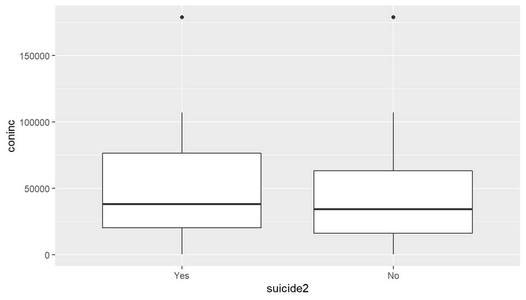

```r
gss2012_S_C <- gss2012 %>%
  filter(suicide2 != 'NA', coninc != 'NA')

ggplot(gss2012_S_C, aes(x = suicide2, y = coninc)) +
  geom_boxplot()
```

## Part 4: Inference

In inference analysis, I analysed confidence interval and hypothesis test. Calculate a 95 per cent confidence interval of the difference between who will suicide if bankrupt or not, with a bootstrap method. Made a comparison of the income means with a hypothesis test with null distribution. This hypothesis test was made with considering who suicide if bankrupt have higher total family income than who do not suicide if bankrupt.

H_0 : mean salary who will suicide if bankrupt is not different from the mean who do not suicide if bankrupt.

H_1 : mean salary who will suicide if bankrupt higher than the mean salary of who do not suicide if bankrupt

# Confidence Interval

```r
inference(y = coninc, x = suicide2, data = gss2012_S_C, statistic = 'mean', type='ci', null = 0, method = 'simulation', boot_method = 'se', nsim = 15000, alternative = 'twosided' )
```

```
## Response variable: numerical, Explanatory variable: categorical (2 levels)
## n_Yes = 132, y_bar_Yes = 58915.9924, s_Yes = 56240.8917
## n_No = 1012, y_bar_No = 46523.6729, s_No = 44907.1672
## 95% CI (Yes - No): (2298.4661 , 22486.1729)
```

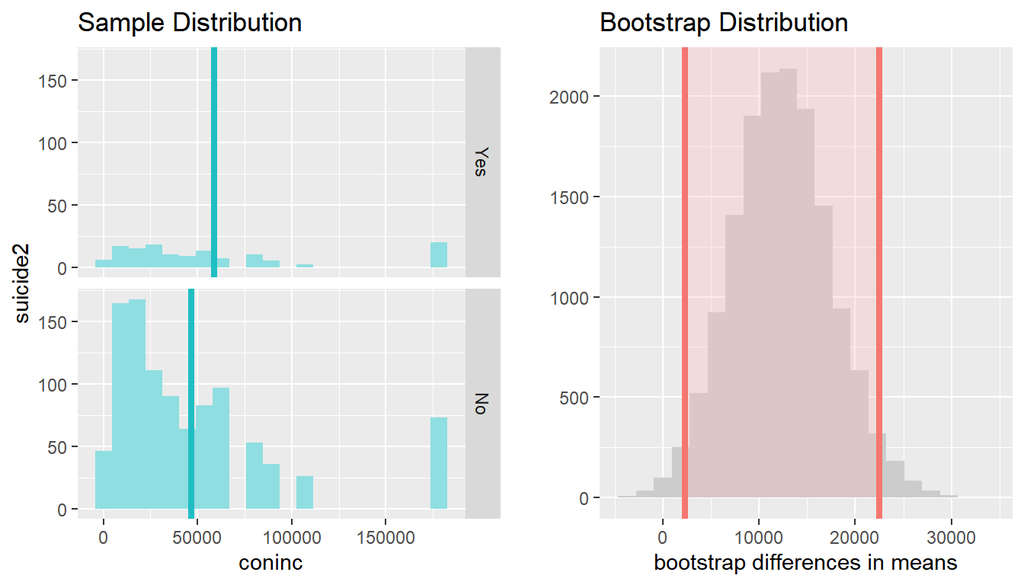

# Hypothesis Tesing

P-value(.0082) is lower than significant level(.05), thus we can rejct the null hypothesis.

```r
inference(y = coninc, x = suicide2, data = gss2012_S_C, statistic = 'mean', type = 'ht', null = 0, alternative = 'greater', method='theoretical')
```

```
## Response variable: numerical
## Explanatory variable: categorical (2 levels)
## n_Yes = 132, y_bar_Yes = 58915.9924, s_Yes = 56240.8917
## n_No = 1012, y_bar_No = 46523.6729, s_No = 44907.1672
## H0: mu_Yes =  mu_No
## HA: mu_Yes > mu_No
## t = 2.4324, df = 131
## p_value = 0.0082
```

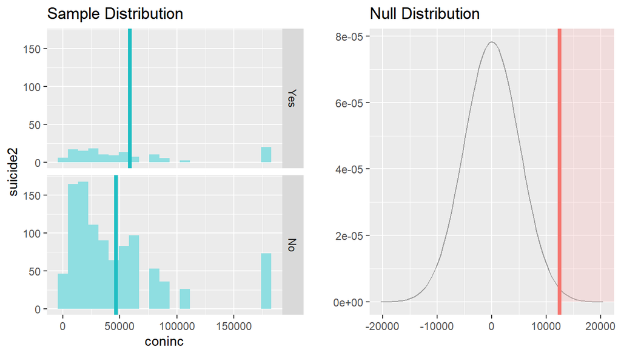

As a result, we can conclude that people who suicide if bankrupt make significantly higher salaries that who do not suicide if bankrupt. This conclusion was reached after performing the hypothesis testing, which yielded a p-value that was indicative of a sufficient evidence to reject the null hypothesis, which was that no difference in mean salaries between people who suicide if bankrupt and who do not.